# MA304-Report: 2212064

Report on Policing Dataset from Dallas, Texas in 2016

Rahul Kithalamane Basavaraj

### Introduction

This is a data set containing **2383 rows and 47 columns**. On the outlook of the data set and on some research it indicates policing equity in 2016. The data indicates how crimes have taken place across the region. All the findings in the data set have been appropriated with right entities and each of their characteristics is clearly understandable in each of the circumstances along with their timings. By further doing some reading on the data set we find that the crimes are of **Dallas, Texas State**. The city is divided into 7 divisions and each place inside a city are identified by area, beat, sector, location_district, street number and street name. The police officers in the city respond to various crimes done by the subject according to their actions. The force used by the officers to respond to a crime depends on the offence done by the subject, reason for force and the subject description. Both the subject and the officers are of mixed races containing both male and females. The different races recorded in this city are **Black, Hispanic, White, Other, Asian and American Ind**. All the incidents are recorded by both date and time. It even records the injury caused to the officers while in pursuit. The experience level by these officers are of varying levels, it contains the young and the most experienced in the lot.

### Data Analysis

Below we have derived a **table** representing the total number of crimes committed by each subject race. To arrive at this output we first filtered out the NULL values and then grouped the data by subject race column. Later I sorted the column in the decreasing order and then used the table function to output the data in the desired format. The output shows that the **Blacks** have committed the most number of crimes in the city totaling 1333, followed by **Hispanic** with 524 crimes and **Whites** committing 470 crimes in the city. The table shows that top 3 crimes committed are by Blacks, Hispanics and Whites and they all dominate in committing crimes in this city. The least number of crimes are committed by American Indians with only 1 recorded incident of committing crime.

Number of Offenses committed by each Subject Race

| Subject Race | Frequency |
| --- | --- |
| Black | 1333 |
| Hispanic | 524 |
| White | 470 |
| Other | 11 |
| Asian | 5 |
| American Ind | 1 |

Here we try to analyze the number of **officers injured in action** by means of a **two way table**. To arrive at this table I selected the columns along officer gender and officer injury. I then used the table function to get the desired output. The below output states that **31 female officers** and **203 male officers** were injured in action. The below data even states that females are in higher percentage of getting injured as compared to males. The number of non injured female officers are 209 and that of non injured male officers are 1940. Less injury also indicates that officers are well equipped and well trained to handle any of the cases.

Number of Officers Injured in action

|  | No | Yes |
| --- | --- | --- |
| Female | 209 | 31 |
| Male | 1940 | 203 |

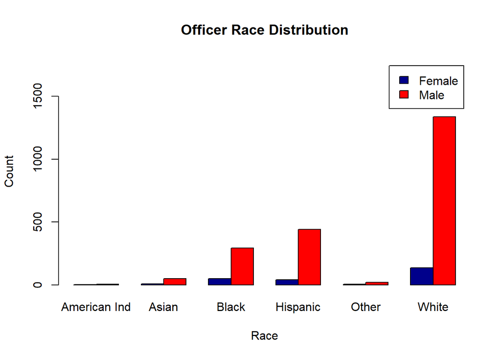

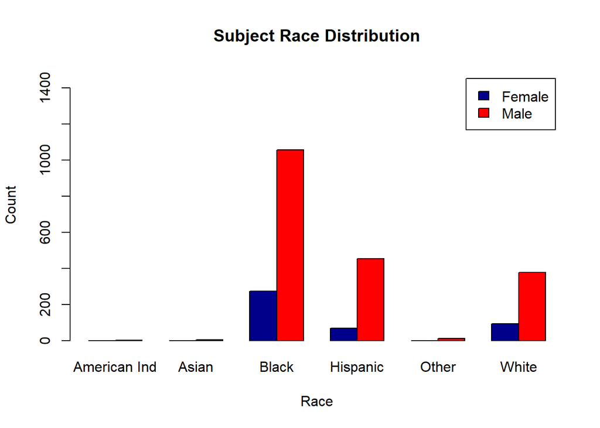

Here I have analysed the crimes committed in Dallas division wise inside the **bar plot**. To arrive at this plot I created a data frame for the division column and then assigned the variables and frequency to the x and y axis inside ggplot. The analysis of bar plot indicates that **563** crimes are committed in the **central** division, followed by the crimes in **southeast** and **northeast** division, this bar plot is an indication that majority of the crimes taking place in Dallas are in the central part of the city.

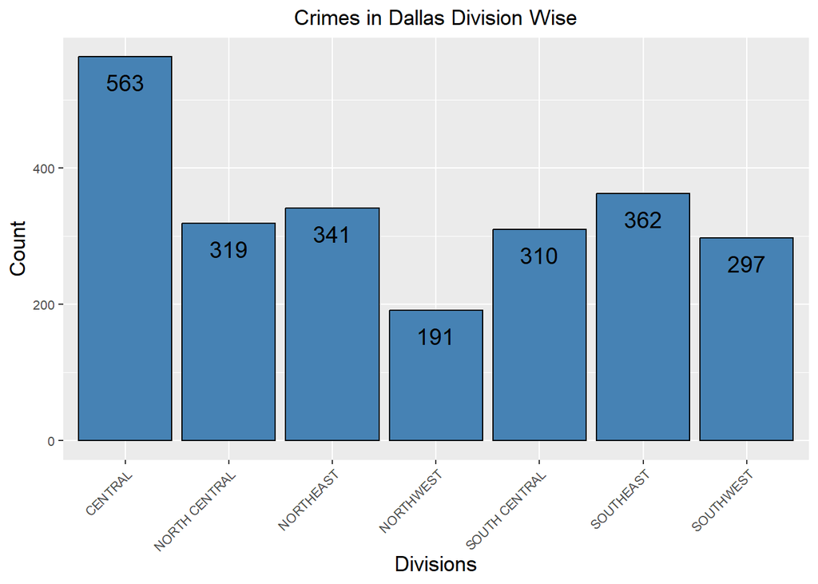

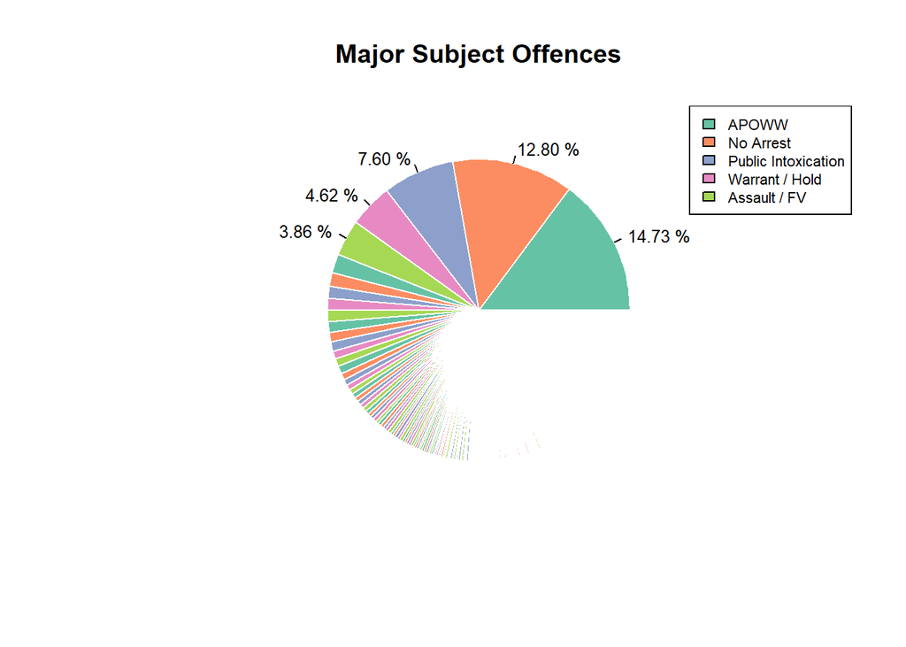

Here we have analysed the data set on the column of **Officers Injury Type** where we created a **pie plot** to visualize the major injury suffered by the officers. It was found that officers 90.64 % of the time suffered **No injuries or visible** marks. Majority of the times officers suffered **Abrasion/Scrape**, this was followed by Laceration/Cut, Sprain/Strain and Redness/Swelling. Out of all the injuries suffered by the subject the maximum percentage of the Officers Injury Type is **3.06 %**. This also indicates the nature of attacks the subjects are going to inflict on the officers.

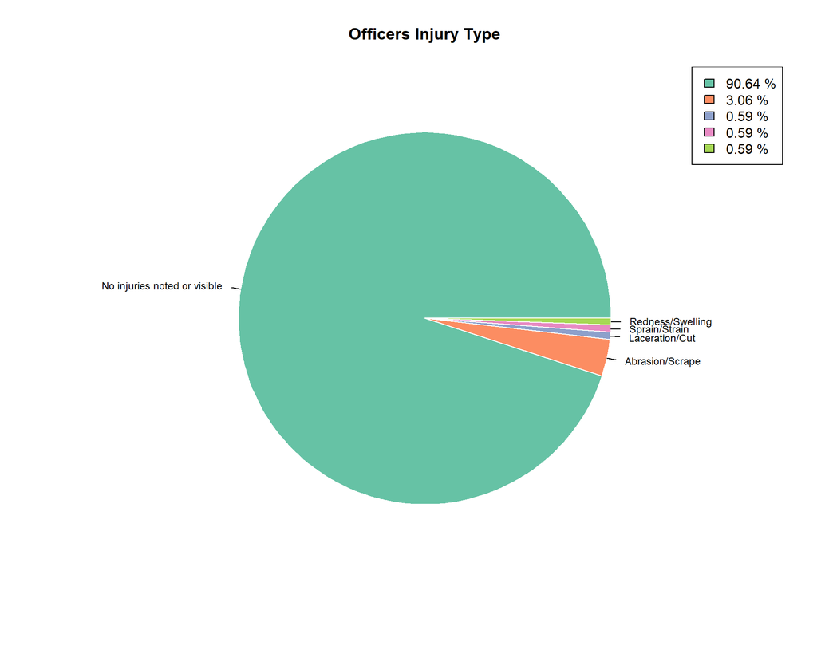

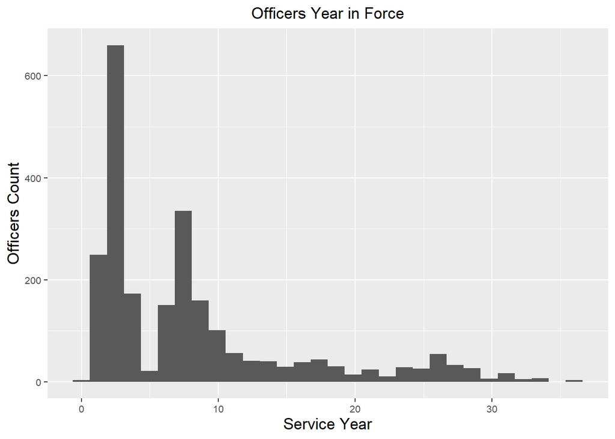

Here is an analysis we conducted for the monthly **count of incidents** taking place in a visualization format i.e, **box plot**. We find that maximum mean of incident count was found in the month of February. This means maximum incidents occurred in the month of **February**. The least count of incidents was found in the month of **December**. The bottom and top lines of a box plot indicates minimum and maximum occurrences of an incident taking place in that month. The black line inside the box plot represents the median. The box plot here represents the range.

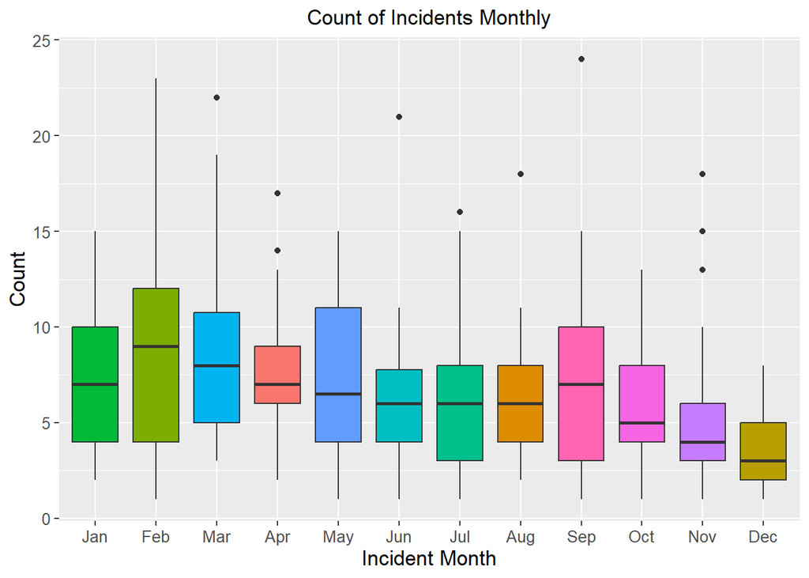

In this analysis we find a pattern of **Incident Rates** among 3 different races i.e, Black, Hispanic and White happening through the year. The incident day trends are captured for the entire year. For these trends we have drawn a **smoothing pattern** using geom_smooth. The trends show that Incident rates are decreasing among Blacks and Hispanics while for white the trends indicate its constant throughout the year. The analysis of trends in the current year helps us in the future prediction of Incident Rate **pattern**.

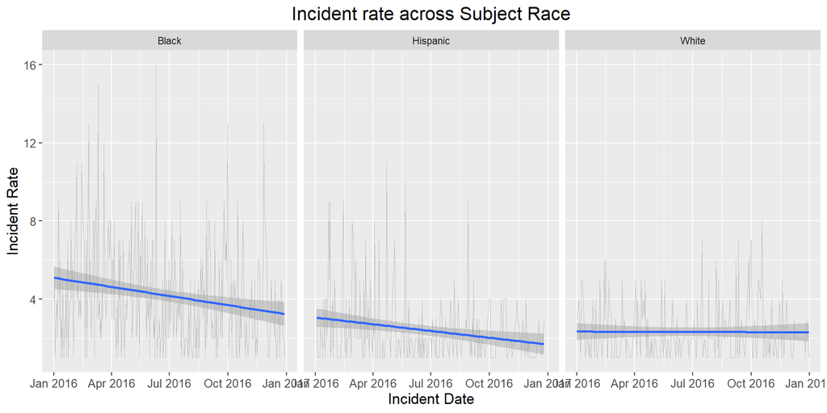

The analysis shows that the incidents concentration is higher during the first **3** hours and the last **8** hours inside this plot. This means that we can predict most of the incidents occurring during this time period. The least incidents are occurred in the **5th hour** to the **10th hour**. To control the incident rate during these peak hours we can put in more officers at this hour of a day. The rescheduling of duty hours of an officer can be done based on this **scatter plot** analysis.

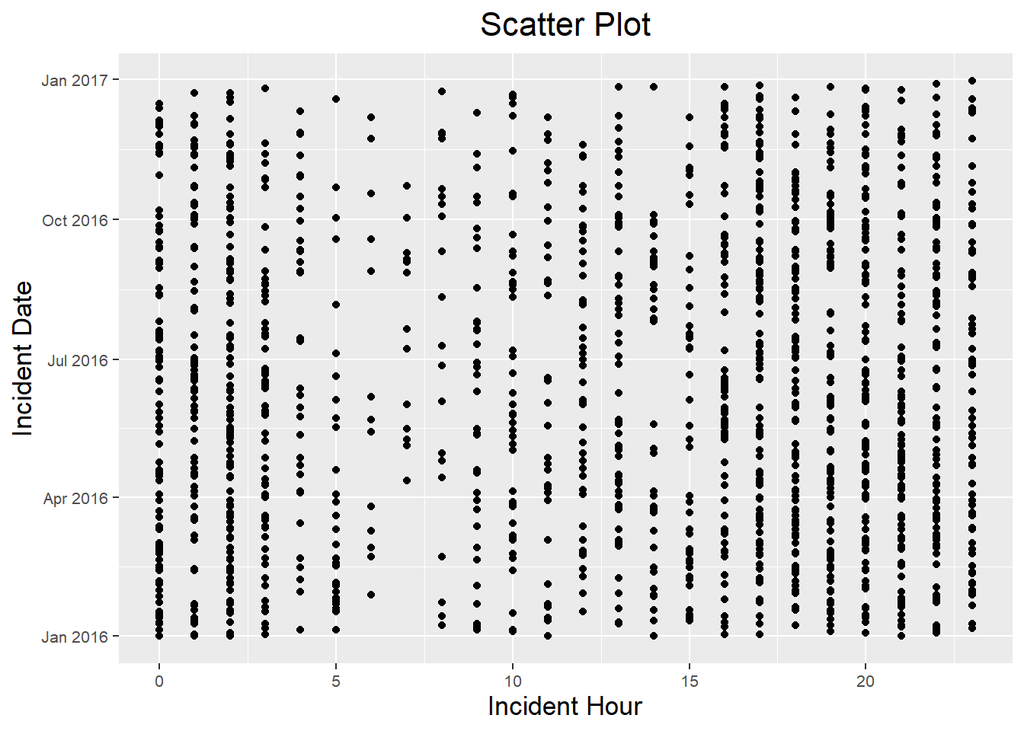

The analysis of **Officer Race Distribution in Each Division** shows that maximum number of male and female officers are present in the central division. Earlier we had found out that maximum crimes happen in the central division, so to tackle the crimes in this division many officers are deployed. The maximum presence of officers indicates maximum likelihood crimes present in that region and minimum presence of officers indicates less crimes in that division. By this **bar plot** we can say that Northwest is the region having the least presence of male and female officers. This might also mean very few crimes in that area.

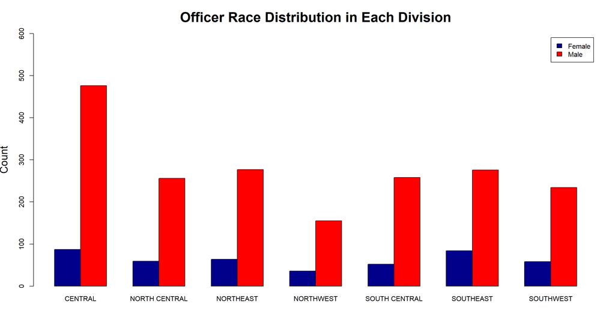

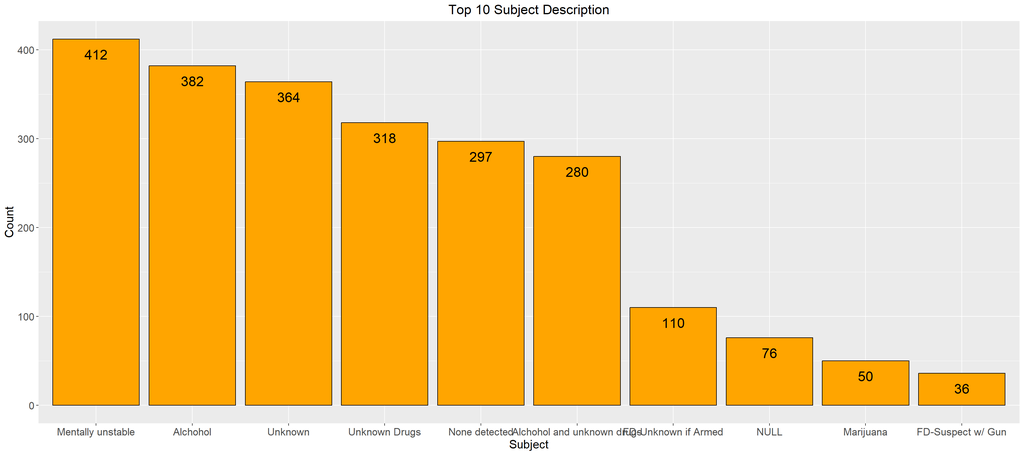

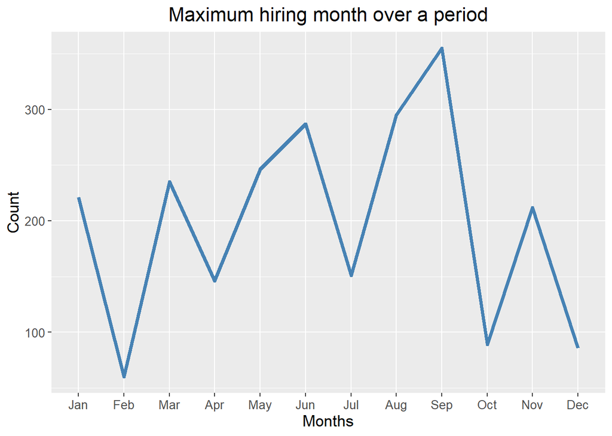

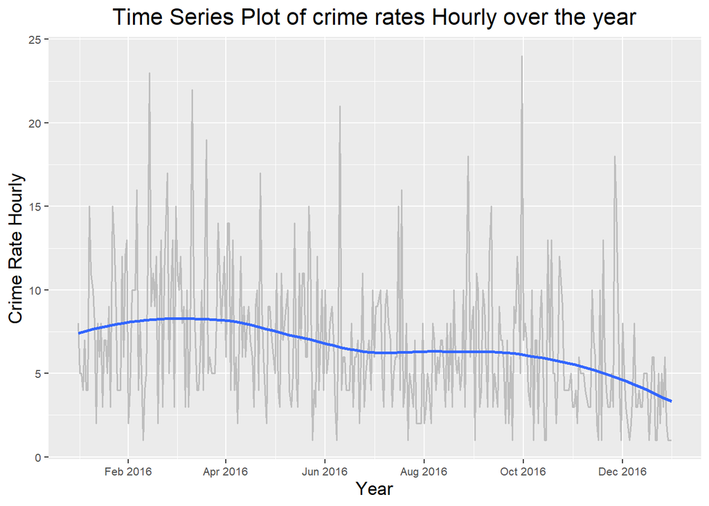

This is a **bar plot** which represents the number of officers **hospitalized** or not while conducting a pursuit. The hospitalization is least among the whites, blacks and Hispanics and is almost null with other races. While the officers are trying to use force, the likelihood of them getting hospitalized is very minimum. This can also state that the officers are well equipped and trained to handle all types of subjects. Here we are basing this bar plot on Officer race distribution and Officer Hospitalization.

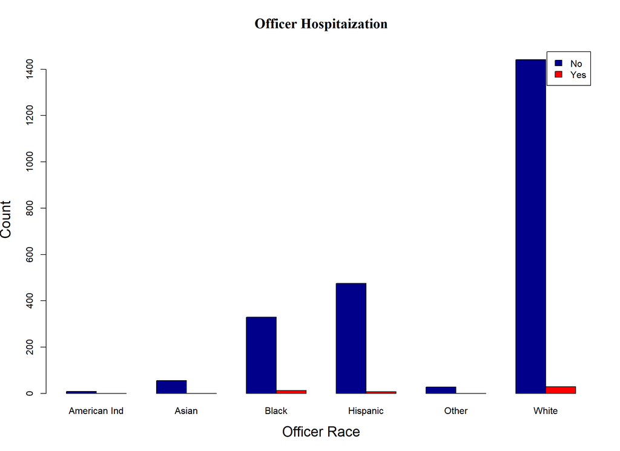

The output shows a **Pearson’s product-moment correlation test** between the variables location district and Street Number. The correlation co-eff value is **0.2832064** which means they are moderately correlated. This also means that if the location is changed the street number also changes. Since the correlation value is positive it is a positive correlation. The 95 percent confidence interval lies in the range of **0.2458484 to 0.3197243**.

```
    Pearson's product-moment correlation

data:  data_dallas$LOCATION_DISTRICT and data_dallas$STREET_NUMBER
t = 14.409, df = 2381, p-value < 2.2e-16
alternative hypothesis: true correlation is not equal to 0
95 percent confidence interval:
 0.2458484 0.3197243
sample estimates:
      cor
0.2832064
```